# Homework 2 Report

## Name

Janavi Kolpekwar

### Setup

Read in the data with `read_csv()` and store the data as an R object named `dataset`. Check the data to make sure all of the expected observations and variables are there.

```r
dataset <- read.csv("maacs.csv.gz")
```

## Part 1

We will first consider the relationship between FEV1 and age. In general, it is expected that as children get older (and hence, larger in size), their FEV1 values should get higher.

Consider the statement “FEV1 values in children are higher in older children relative to younger children”.

Write a function in R that takes the `dataset` object as an argument and returns `TRUE` if the statement above is true for the dataset and `FALSE` otherwise.

NOTE: In order to write this function, you will need to translate the statement above into something that can be checked with the data. There are many ways in which you can do that translation correctly and you only need to pick one way here.

NOTE: For this part, do not use any plots.

```r
library(dplyr)
```

```r
library(tidyr)
library(ggplot2)
```

```r
check_fev1_age <- function(dataset) {

  med_age <- median(dataset$age, na.rm = TRUE)

  dataset %>%
    mutate(age_group = if_else(age < med_age, "younger", "older")) %>%
    group_by(age_group) %>%
    summarize(mean = mean(fev1, na.rm = TRUE),
              median = median(fev1, na.rm = TRUE),
              .groups = "drop") %>%
    pivot_longer(-age_group) %>%
    pivot_wider(names_from = age_group, values_from = value) %>%
    mutate(diff = older - younger) %>%
    filter(name == "mean") %>%
    pull(diff) > 0
}
result <- check_fev1_age(dataset)
print(result)
```

```
## [1] TRUE
```

## Part 2

Fit a linear regression model with FEV1 as the outcome and age as a predictor.

How much does FEV1 change for a 1-year increase in the child’s age?

```r
# linear regression model (age -> predictor, FEV1 -> outcome)
fit <- lm(fev1 ~ age, data = dataset)
summary(fit)
```

```
##
## Call:
## lm(formula = fev1 ~ age, data = dataset)
##
## Residuals:
##      Min       1Q   Median       3Q      Max
## -1.51099 -0.27100  0.00196  0.23616  2.15477
##
## Coefficients:
##              Estimate Std. Error t value Pr(>|t|)
## (Intercept) -0.001199   0.134696  -0.009    0.993
## age          0.171162   0.010984  15.583   <2e-16 ***
## ---
## Signif. codes:  0 '***' 0.001 '**' 0.01 '*' 0.05 '.' 0.1 ' ' 1
##
## Residual standard error: 0.4827 on 131 degrees of freedom
##   (17 observations deleted due to missingness)
## Multiple R-squared:  0.6496, Adjusted R-squared:  0.6469
## F-statistic: 242.8 on 1 and 131 DF,  p-value: < 2.2e-16
```

```r
coef(fit)["age"]
```

```
##       age
## 0.1711623
```

On average, FEV1 increases by about 0.171 liters for every 1-year increase in age.

## Part 3

Develop **three** supporting premises derived from the data that support the statement you wrote in Part 2. These can be plots, other summary statistics, or model results.

NOTE: At least one supporting premise should use a plot.

```r
## Premise 1: correlation between age and FEV1
cor_val <- cor(dataset$age, dataset$fev1, use = "complete.obs")
cor_val
```

```
## [1] 0.8059696
```

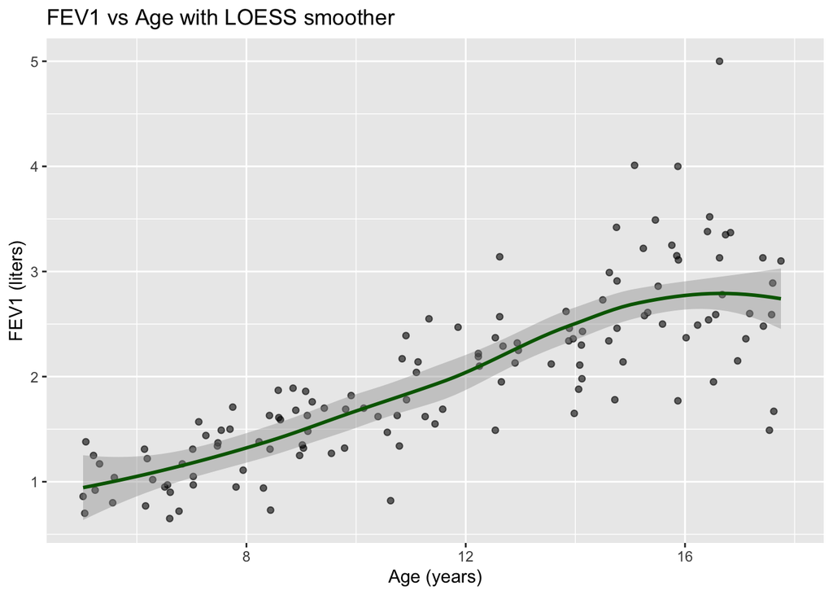

```r
## Premise 2: scatterplot with geom_smooth
ggplot(dataset, aes(x = age, y = fev1)) +
  geom_point(alpha = 0.6) +
  geom_smooth(method = "loess", se = TRUE, color = "darkgreen") +
  labs(title = "FEV1 vs Age with LOESS smoother",
       x = "Age (years)", y = "FEV1 (liters)")
```

```r
## Premise 3: compare spread using quantiles
quant_summary <- dataset %>%
  summarize(
    q25_age = quantile(age, 0.25, na.rm = TRUE),
    q75_age = quantile(age, 0.75, na.rm = TRUE),
    q25_fev1 = quantile(fev1, 0.25, na.rm = TRUE),
    q75_fev1 = quantile(fev1, 0.75, na.rm = TRUE)
  )
print(quant_summary)
```

```
##   q25_age q75_age q25_fev1 q75_fev1
## 1  7.7125 14.7575     1.37     2.49
```

Write the three supporting premise statements here:

1. The correlation between age and FEV1 is positive (≈ 0.80), showing that as age increases, FEV1 tends to increase as well.
2. A scatterplot of FEV1 versus age with a LOESS smoother shows a clear upward curve, confirming visually that FEV1 values rise as children get older.
3. Children in the upper quartile of age also have substantially higher FEV1 values than those in the lower quartile, indicating that the overall distribution of FEV1 shifts upward with age.

## Part 4

For each of the supporting premises above, write a function that takes the `dataset` object as an argument and returns `TRUE` if the supporting premise statement above is true for the dataset and `FALSE` otherwise.

For statements involving plots, instead of returning `TRUE` or `FALSE`, you function should do two things:

1. Produce the plot that is used in the statement
2. Produce a hypothetical version of the plot in the event that the statement is true. This can be done using simulated data or by simply hand drawing a plot.

```r
## Function for supporting premise statement 1
premise1_correlation <- function(dataset) {
  cor_val <- cor(dataset$age, dataset$fev1, use = "complete.obs")
  message(sprintf("Correlation(age, FEV1) = %.3f", cor_val))
  cor_val > 0
}
```

```r
## Function for supporting premise statement 2
premise2_scatter_loess <- function(dataset) {
  p_actual <- ggplot(dataset, aes(x = age, y = fev1)) +
    geom_point(alpha = 0.6) +
    geom_smooth(method = "loess", se = TRUE) +
    labs(title = "Actual: FEV1 vs Age (LOESS smoother)",
         x = "Age (years)", y = "FEV1 (liters)")
  print(p_actual)
  set.seed(123)
  n <- nrow(dataset)
  age_sim <- sort(dataset$age)
  fev1_sim <- 0.5 + 0.20*age_sim + rnorm(n, mean = 0, sd = 0.15)

  simdat <- data.frame(age = age_sim, fev1 = fev1_sim)
  p_hyp <- ggplot(simdat, aes(x = age, y = fev1)) +
    geom_point(alpha = 0.6) +
    geom_smooth(method = "loess", se = TRUE) +
    labs(title = "Hypothetical (If Statement is True): FEV1 rises with Age",
         x = "Age (years)", y = "FEV1 (liters)")
  print(p_hyp)
  invisible(NULL)
}
```

```r
# Function for supporting premise statement 3
premise3_age_quartile_medians <- function(dataset) {
  qs <- quantile(dataset$age, probs = c(0.25, 0.75), na.rm = TRUE)
  q1 <- dataset$fev1[dataset$age <= qs[1]]
  q4 <- dataset$fev1[dataset$age >= qs[2]]
  med_q1 <- median(q1, na.rm = TRUE)
  med_q4 <- median(q4, na.rm = TRUE)
  message(sprintf("Median FEV1 (youngest quartile): %.3f", med_q1))
  message(sprintf("Median FEV1 (oldest quartile):   %.3f", med_q4))
  med_q4 > med_q1
}
```

Function Outputs:

```r
# Function 1: Output
res1 <- premise1_correlation(dataset)
```

```
## Correlation(age, FEV1) = 0.806
```

```r
print(res1)
```

```
## [1] TRUE
```

The correlation coefficient of 0.806 is close to +1, meaning there’s a strong positive relationship: older children tend to have higher FEV1 values.

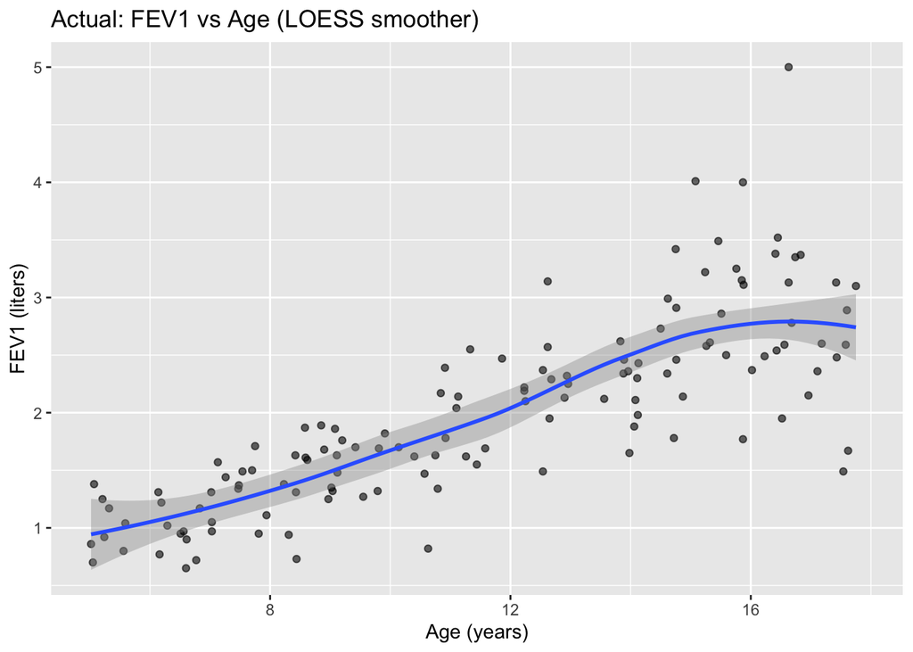

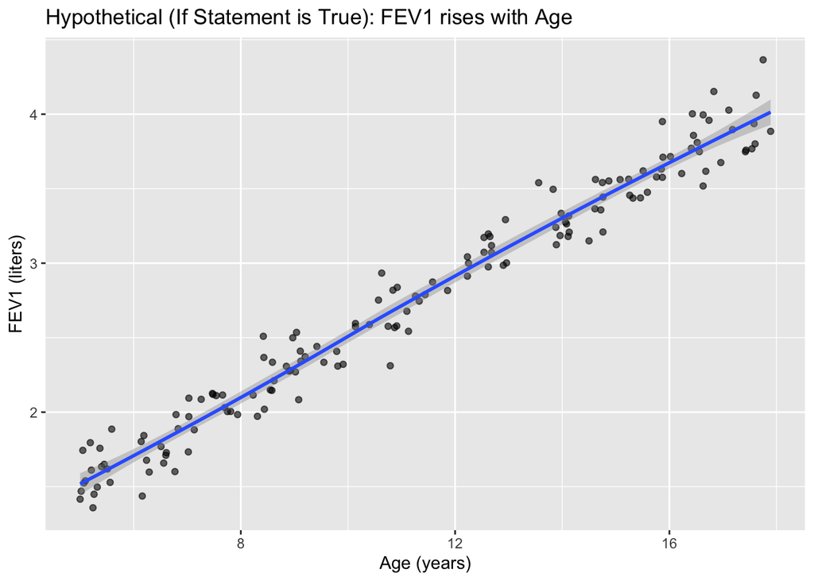

```r
# Function 2: Output
premise2_scatter_loess(dataset)
```

```r
# Function 3: Output
res3 <- premise3_age_quartile_medians(dataset)
```

```
## Median FEV1 (youngest quartile): 1.050
```

```
## Median FEV1 (oldest quartile):   2.780
```

```r
print(res3)
```

```
## [1] TRUE
```

The function compares the median FEV1 values of the youngest quartile (1.050) and the oldest quartile (2.780). Since the median FEV1 in the oldest quartile is higher than in the youngest quartile, the function outputs TRUE.This supports the premise that FEV1 values increase with age, as even when looking at quartile-based comparisons, older children show higher FEV1 values than younger children.

## Part 5

Describe one alternative to the primary statement “FEV1 values in children are higher in older children relative to younger children”.

Alternative Outcome: FEV1 values are the same in younger children and in older children.